# Chapter 9 question 4,5

Mukul Goyal

October 22, 2019

## Question 4

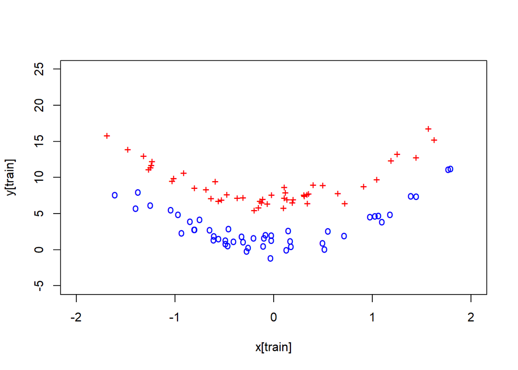

```r
set.seed(191)
x = rnorm(100)
y = 3 * x^2 + 4 + rnorm(100)
train = sample(100,50)
y[train] = y[train] + 3
y[-train] = y[-train] - 3
plot(x[train], y[train], pch="+", lwd=4, col="red", ylim = c(-5,25), xlim=c(-2,2))
points(x[-train], y[-train], pch="o", lwd=4, col="blue")
```

We will now create a new vector `z` for classes, which will contain 0 and 1 according to classes.

```r
z = rep(0,100)
z[train] = 1
#take 25 observation each from train and -train
#setdiif is used to take difference between index positions 1:100 and train.
final.train = c(sample(train,25), sample(setdiff(1:100, train),25))

data.train = data.frame(x = x[final.train], y= y[final.train], z= as.factor(z[final.train]))


data.test = data.frame(x= x[-final.train], y= y[-final.train], z=as.factor(z[-final.train]))
```

First we will fit support vector classifier.

```r
library(e1071)
```

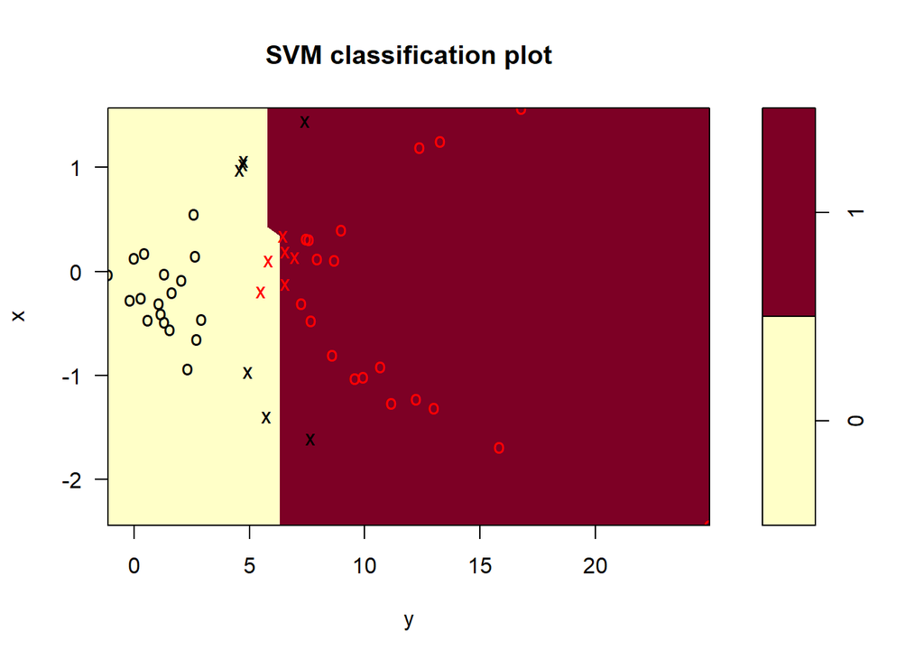

```r
svm.linear = svm(z~. , data= data.train, kernel= "linear", cost=10)
plot(svm.linear, data.train)
```

We can now get mis-classification table:

```r
table1 = table(z[final.train], predict(svm.linear, data.train))
table1
```

```
##
##      0  1
##   0 23  2
##   1  2 23
```

Mis- classification rate:

```r
(table1[2] + table1[3])/50
```

```
## [1] 0.08
```

Now, we will train SVM with polynomial kernel:

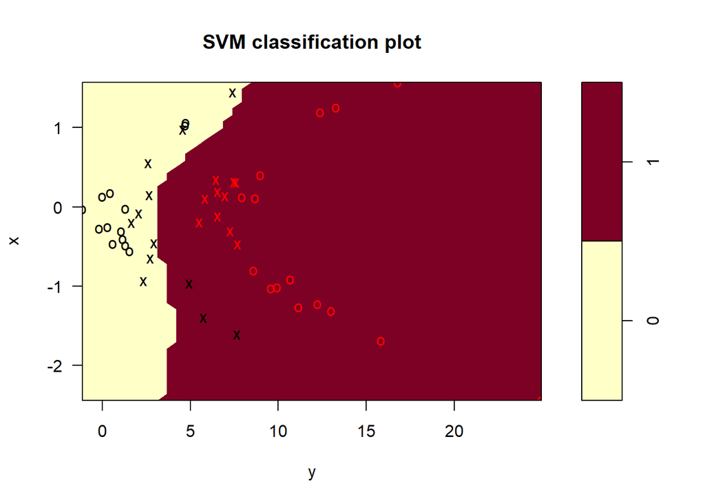

```r
svm.poly = svm(z~. , data= data.train, kernel="polynomial", cost=10)
plot(svm.poly, data.train)
```

Mis- classification rate with polynomial kernel:

```r
table1 = table(z[final.train], predict(svm.poly, data.train))
table1
```

```
##
##      0  1
##   0 21  4
##   1  0 25
```

```r
(table1[2] + table1[3])/50
```

```
## [1] 0.08
```

We will now try SVM with radial kernel.

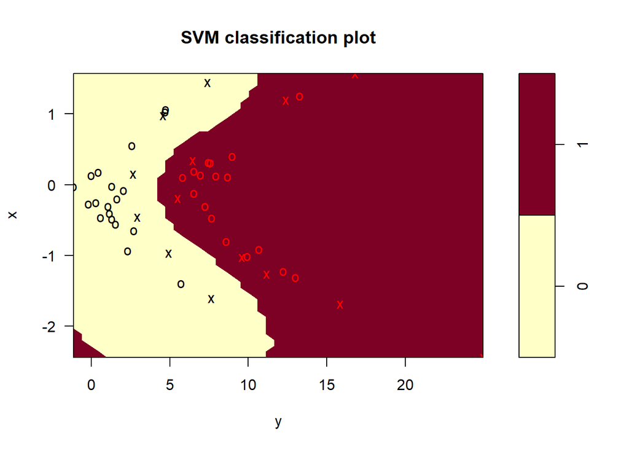

```r
svm.radial = svm(z~., data= data.train, kernel="radial", gamma= 1, cost=10)
plot(svm.radial, data.train)
```

Now, checking mis-classification rate:

```r
table1 = table(z[final.train], predict(svm.radial,data.train))
table1
```

```
##
##      0  1
##   0 25  0
##   1  0 25
```

```r
(table1[2] + table1[3])/50
```

```
## [1] 0
```

Lowest error rate for radial SVM.

now checking for test data

1. Support vector classifier

```r
table1 = table(z[-final.train], predict(svm.linear, data.test))
table1
```

```
##
##      0  1
##   0 18  7
##   1  1 24
```

```r
(table1[2] + table1[3])/50
```

```
## [1] 0.16
```

2. SVM- Polynomial

```r
table1 = table(z[-final.train], predict(svm.poly, data.test))
table1
```

```
##
##      0  1
##   0 16  9
##   1  0 25
```

Mis- classification error rate

```r
(table1[2] + table1[3])/50
```

```
## [1] 0.18
```

3. Radial SVM

```r
table1 = table(z[-final.train], predict(svm.radial, data.test))
table1
```

```
##
##      0  1
##   0 21  4
##   1  1 24
```

```r
(table1[2] + table1[3])/50
```

```
## [1] 0.1
```

Radial gives lowest test error rate.

# Question 5

```r
set.seed(99)
x1 = runif(500)-0.5
x2 = runif(500)-0.5
y = 1*(x1^2 - x2^2 > 0)
```

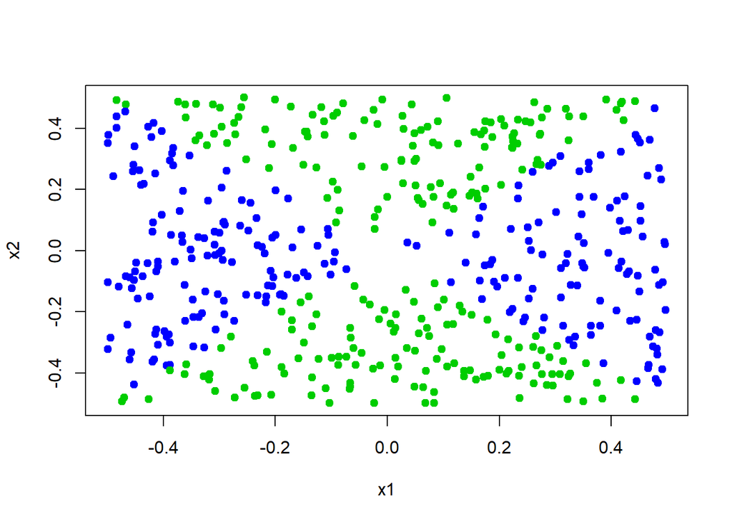

```r
plot(x1,x2, pch=19, col=y+3)
```

```r
data.sim = data.frame(x1=x1,x2=x2, y=y)
```

```r
train = sample(500,300)
```

```r
library(glmnet)
log.reg = glm(y~., data= data.sim[train,], family="binomial")
summary(log.reg)
```

```
##
## Call:
## glm(formula = y ~ ., family = "binomial", data = data.sim[train,
##     ])
##
## Deviance Residuals:
##    Min      1Q  Median      3Q     Max
## -1.366  -1.188   1.025   1.145   1.334
##
## Coefficients:
##             Estimate Std. Error z value Pr(>|z|)
## (Intercept)  0.03269    0.11606   0.282    0.778
## x1          -0.45887    0.38931  -1.179    0.239
## x2          -0.37264    0.38335  -0.972    0.331
##
## (Dispersion parameter for binomial family taken to be 1)
##
##     Null deviance: 415.77  on 299  degrees of freedom
## Residual deviance: 413.54  on 297  degrees of freedom
## AIC: 419.54
##
## Number of Fisher Scoring iterations: 3
```

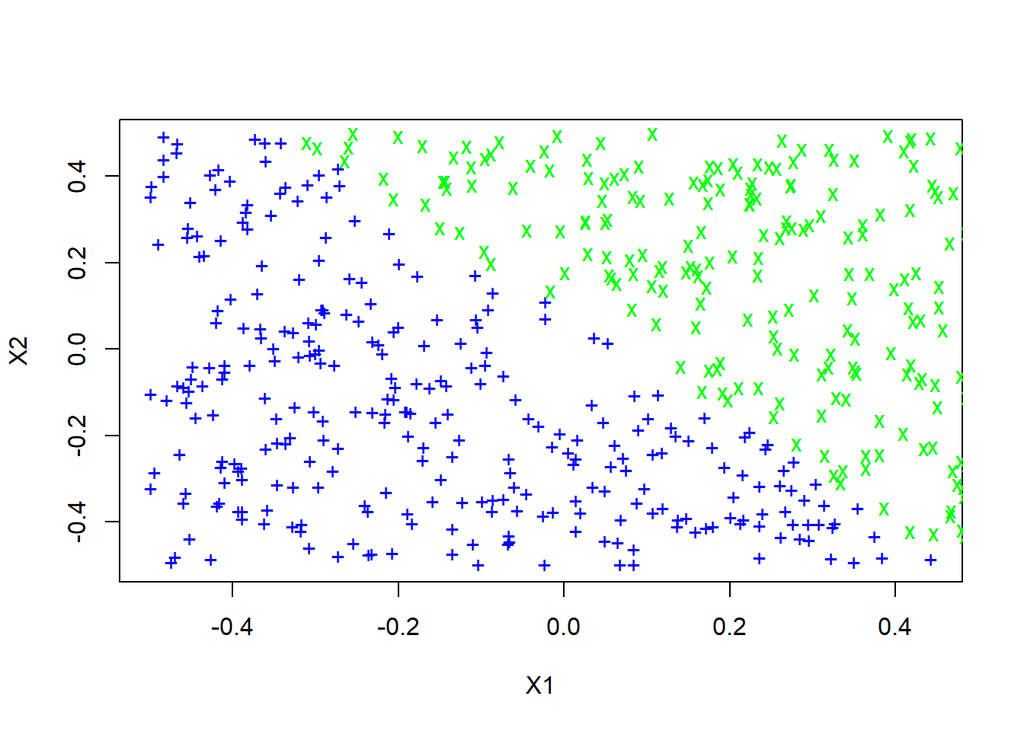

```r
prob = predict(log.reg, newdata = data.sim, type="response")
lm.pred = ifelse(prob>0.5,1,0)
plot(data.sim[lm.pred==1,]$x1,data.sim[lm.pred==1,]$x2 ,col="blue", xlab="X1", ylab="X2", pch= "+")
points(data.sim[lm.pred==0,]$x1,data.sim[lm.pred==0,]$x2 ,col="green", pch= "x")
```

We can see from above that decision boundary is linear.

Now, we will be fitting logistic regression using non-linear functions of X.

```r
log.1 = glm(y~ x1+I(x1^2)+x2, family = "binomial", data= data.sim)
summary(log.1)
```

```
##
## Call:
## glm(formula = y ~ x1 + I(x1^2) + x2, family = "binomial", data = data.sim)
##
## Deviance Residuals:
##     Min       1Q   Median       3Q      Max
## -2.6242  -0.7432  -0.5568   0.7916   1.9227
##
## Coefficients:
##             Estimate Std. Error z value Pr(>|z|)
## (Intercept)  -1.6659     0.1750  -9.518   <2e-16 ***
## x1           -0.7943     0.4048  -1.962   0.0498 *
## I(x1^2)      20.1966     1.8839  10.721   <2e-16 ***
## x2           -0.3375     0.3656  -0.923   0.3559
## ---
## Signif. codes:  0 '***' 0.001 '**' 0.01 '*' 0.05 '.' 0.1 ' ' 1
##
## (Dispersion parameter for binomial family taken to be 1)
##
##     Null deviance: 692.86  on 499  degrees of freedom
## Residual deviance: 512.64  on 496  degrees of freedom
## AIC: 520.64
##
## Number of Fisher Scoring iterations: 4
```

We can see that polynomial term of x1 is significant as seen by p- value.

Checking other model:

```r
log.2 = glm(y~ I(x1^2)+I(x1*x2), family = "binomial", data= data.sim)
summary(log.2)
```

```
##
## Call:
## glm(formula = y ~ I(x1^2) + I(x1 * x2), family = "binomial",
##     data = data.sim)
##
## Deviance Residuals:
##     Min       1Q   Median       3Q      Max
## -2.4673  -0.7483  -0.5907   0.8186   1.9039
##
## Coefficients:
##             Estimate Std. Error z value Pr(>|z|)
## (Intercept)  -1.6603     0.1744  -9.519   <2e-16 ***
## I(x1^2)      20.0859     1.8781  10.695   <2e-16 ***
## I(x1 * x2)    0.1097     1.3551   0.081    0.936
## ---
## Signif. codes:  0 '***' 0.001 '**' 0.01 '*' 0.05 '.' 0.1 ' ' 1
##
## (Dispersion parameter for binomial family taken to be 1)
##
##     Null deviance: 692.86  on 499  degrees of freedom
## Residual deviance: 517.31  on 497  degrees of freedom
## AIC: 523.31
##
## Number of Fisher Scoring iterations: 4
```

x1*x2 term is not significant

Checking other model:

```r
log.3 = glm(y~ I(x1^2)+I(x2^2), family = "binomial", data= data.sim)
summary(log.3)
```

```
##
## Call:
## glm(formula = y ~ I(x1^2) + I(x2^2), family = "binomial", data = data.sim)
##
## Deviance Residuals:
##        Min          1Q      Median          3Q         Max
## -2.410e-03  -2.000e-08  -2.000e-08   2.000e-08   2.451e-03
##
## Coefficients:
##               Estimate Std. Error z value Pr(>|z|)
## (Intercept)     -7.173    313.669  -0.023    0.982
## I(x1^2)      32303.810 632877.321   0.051    0.959
## I(x2^2)     -32298.414 630535.723  -0.051    0.959
##
## (Dispersion parameter for binomial family taken to be 1)
##
##     Null deviance: 6.9286e+02  on 499  degrees of freedom
## Residual deviance: 1.1955e-05  on 497  degrees of freedom
## AIC: 6
##
## Number of Fisher Scoring iterations: 25
```

Not much of value.

Checking other model:

```r
log.4 = glm(y~ I(x1^2)+log(x2)+x2, family = "binomial", data= data.sim)
summary(log.4)
```

```
##
## Call:
## glm(formula = y ~ I(x1^2) + log(x2) + x2, family = "binomial",
##     data = data.sim)
##
## Deviance Residuals:
##      Min        1Q    Median        3Q       Max
## -2.08267  -0.01502  -0.00004   0.01239   1.81787
##
## Coefficients:
##             Estimate Std. Error z value Pr(>|z|)
## (Intercept)   15.398      4.943   3.115  0.00184 **
## I(x1^2)      120.382     26.584   4.528 5.94e-06 ***
## log(x2)        3.289      1.270   2.590  0.00960 **
## x2           -79.481     19.795  -4.015 5.94e-05 ***
## ---
## Signif. codes:  0 '***' 0.001 '**' 0.01 '*' 0.05 '.' 0.1 ' ' 1
##
## (Dispersion parameter for binomial family taken to be 1)
##
##     Null deviance: 320.732  on 232  degrees of freedom
## Residual deviance:  48.776  on 229  degrees of freedom
##   (267 observations deleted due to missingness)
## AIC: 56.776
##
## Number of Fisher Scoring iterations: 9
```

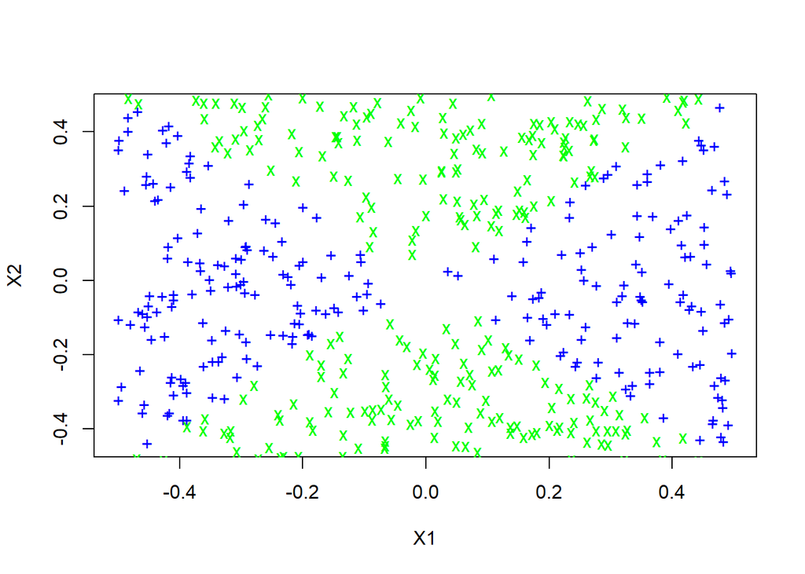

```r
prob = predict(log.3, newdata = data.sim, type="response")
lm.pred = ifelse(prob>0.5,1,0)
plot(data.sim[lm.pred==1,]$x1,data.sim[lm.pred==1,]$x2 ,col="blue", xlab="X1", ylab="X2", pch= "+")
points(data.sim[lm.pred==0,]$x1,data.sim[lm.pred==0,]$x2 ,col="green", pch= "x")
```

Model with $x_{1}^2$ and $x_{2}^2$ term gives non- linear boundary and closely resemble to true decision boundary.

Fitting a support vector classifier to the model

```r
library(e1071)
```

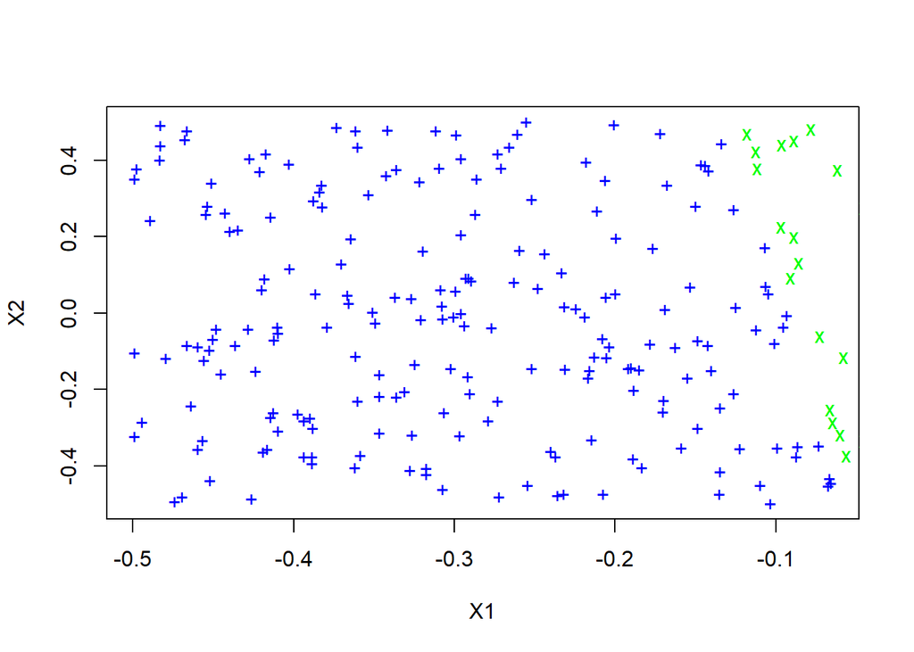

```r
svc = svm(as.factor(y)~ x1 + x2 , data = data.sim, kernel = "linear", cost= 10)
svc.pred =  predict(svc, data.sim)
plot(data.sim[svc.pred==1,]$x1,data.sim[svc.pred==1,]$x2 ,col="blue", xlab="X1", ylab="X2", pch= "+")
points(data.sim[svc.pred==0,]$x1,data.sim[svc.pred==0,]$x2 ,col="green", pch= "x")
```

A support vector classofier gives a linear boundary.

We will now fit SVM using a non linear kernel:

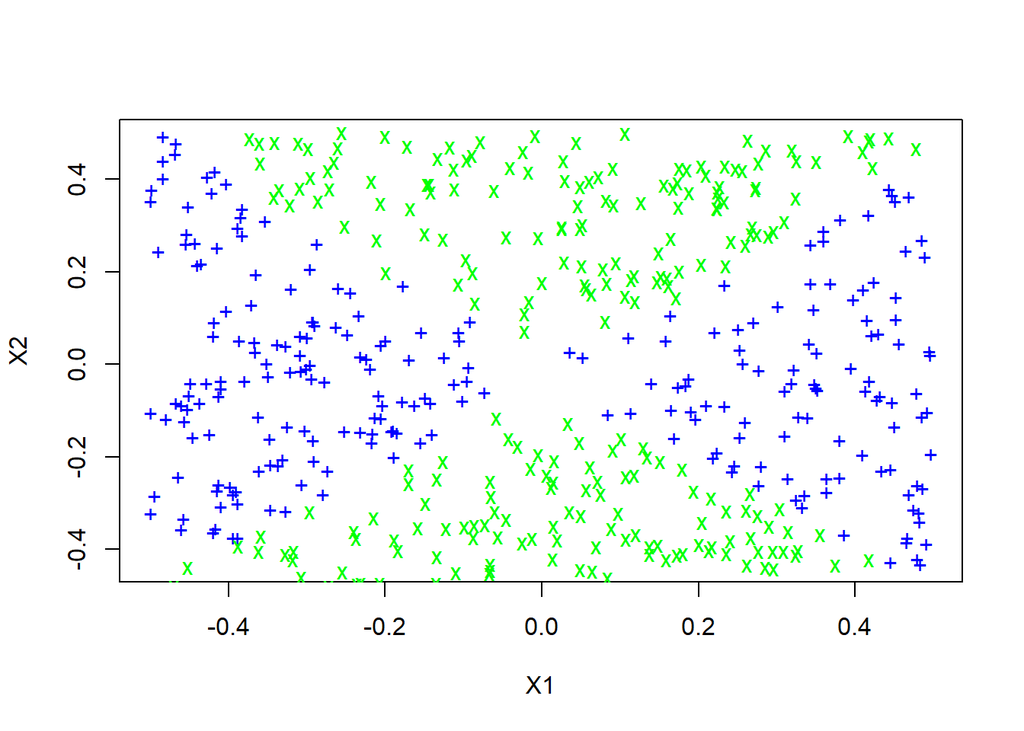

```r
svm.radial = svm(as.factor(y)~., data = data.sim, kernel = "radial", gamma=1, cost=1)
svm.pred =  predict(svm.radial, data.sim, type="class")
plot(data.sim[svm.pred==1,]$x1,data.sim[svm.pred==1,]$x2 ,col="blue", xlab="X1", ylab="X2", pch= "+")
points(data.sim[svm.pred==0,]$x1,data.sim[svm.pred==0,]$x2 ,col="green", pch= "x")
```

Produces a decision boundary close to true decision boundary.